# Hypothesis Testing

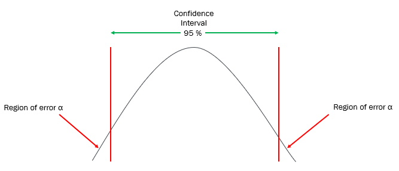

*Hypothesis testing is to utilize statistics to prove or disprove assumptions*

*Steps involved*

1. Say, a statement: It is not healthy to drink sweetened carbonated drink on daily basis.
   - The statement above is a hypothesis, and we will have to capture *data* aligned to this problem statement.
   - The data collection may have to involve people of both kinds of certain age. (One who drinks and one who does not)
   - The data should be testable and correlate to the problem statement.
2. Once we have the problem statment, for statistical analysis, we make a *null hypothesis* and *alternate hypothesis*
   - *null hypothesis* is usually against the statement to be proven. for the case as this the statement would be, sweetened carbonated drinks have no effect on health.
   - *alternate hypothesis* is in line with statement to be proven.
3. The null hypothesis *H<sub>o</sub>* and *H<sub>1</sub>* are mutually exclusive. (In other words, only one can occur. There is no scope of overlap within them)
4. Next is to apply statistical testing and obtain *p-value*
   - alpha α is the error term (significance level) (at 95% confidence, the error is 5%. 2.5% error at each ends of distribution)
   - in a one sided hypothesis testing, error remains only on one end.
   - Imagine this as that there is no scope of value to be present on one end, so the error can occur only on either right or left.
   - When the *p-value* is less than the error α (0.05 or 5%) we reject null hypothesis *H<sub>o</sub>* as the mean is not present in the error region. (No statistical evidence, mean is somwhere in 95% confidence interval)
   - When the *p-value* is greater than the error α (0.05 or 5%) we reject alternate hypothesis *H<sub>1</sub>* as the mean is present in the error region. (statistical evidence, the mean may be present in 5% error region)

*Type I and Type II errors* There is possibility that we make wrong interpretations based on the *p-value* observed. The wrong *p-value* may be due to wrong data or making wrong assumptions.

It boils down to the fact that we can make 2 kinds of errors.

- *Type I* - We reject the null hypothesis erroneously when it should not have been rejected. *H<sub>1</sub>* is accepted to be correct but in real this is wrong.
- *Type II* - We do not reject the null hypothesis erroneously when it should have been rejected. *H<sub>0</sub>* is accepted to be correct but in real this is wrong.

*code credits*: https://www.kaggle.com/code/hamelg/python-for-data-24-hypothesis-testing#Type-I-and-Type-II-Error